# Научная презентация по лабораторной работе №9

Дисциплина:Операционные системы

Абрамова У. М.

Российский университет дружбы народов, Москва, Россия

Математический институт имени Никольского, Москва, Россия

05.04.2025

# Информация

## Докладчик

- Абрамова Ульяна Михайловна
- Студент НММбд-01-24
- Российский университет дружбы народов
- 1132246782@pfur.ru
- https://github.com/Ulyana-abr

# Вводная часть

## Актуальность

- Работа с файловой системой Linux актуальна, так как эта операционная система широко используется, в том числе среди разработчиков.

## Цели и задачи

- Освоение основных возможностей командной оболочки Midnight Commander.
- Приобретение навыков практической работы по просмотру каталогов и файлов; манипуляций с ними.

## Материалы и методы

- linux

## Содержание исследования

### Задание по mc

Изучаю информацию о mc, вызвав в командной строке man mc (рис. 1).

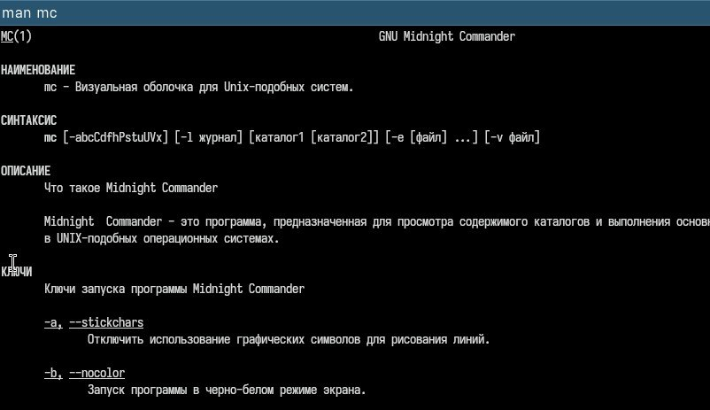

man

## Содержание исследования

Выполняю несколько операций в mc, используя управляющие клавиши (рис. 2, 3, 4)

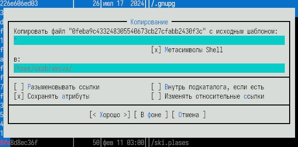

копирование файлов

## Содержание исследования

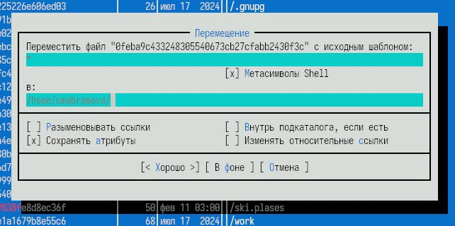

перемещение файлов

## Содержание исследования

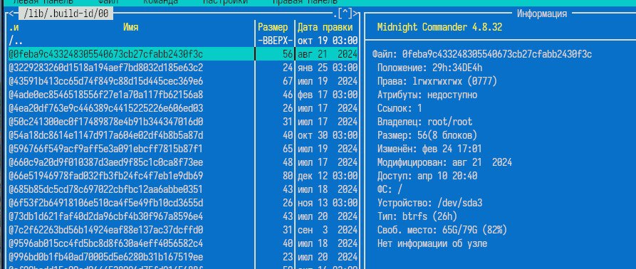

получение информации о размере и правах доступа на файлы

## Содержание исследования

Выполняю основные команды меню правой панели (рис. 4, 5, 6)

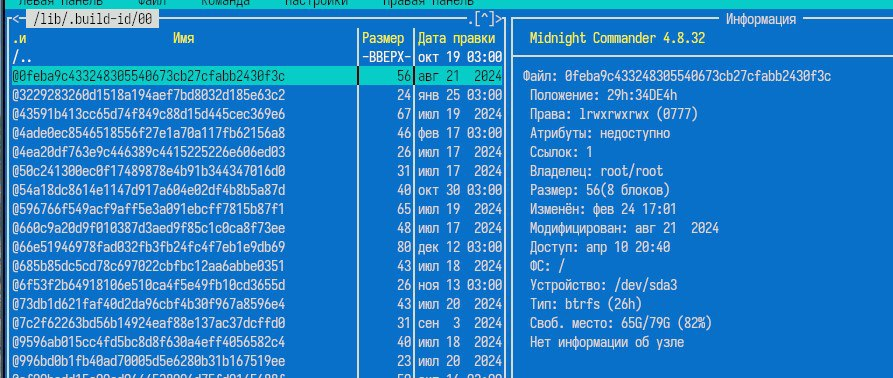

## Содержание исследования

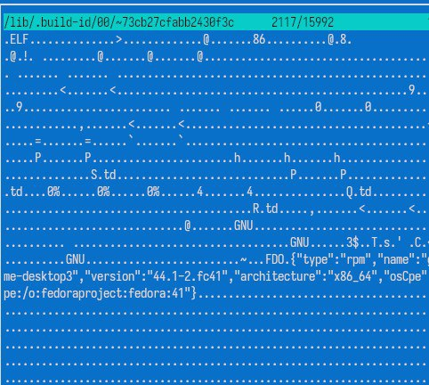

быстрый просмотр

## Содержание исследования

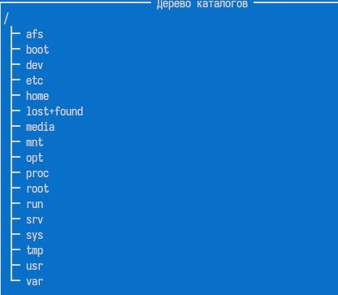

дерево каталогов

## Содержание исследования

Используя возможности подменю Файл , выполняю различные команды (рис. 7, 8, 9, 10)

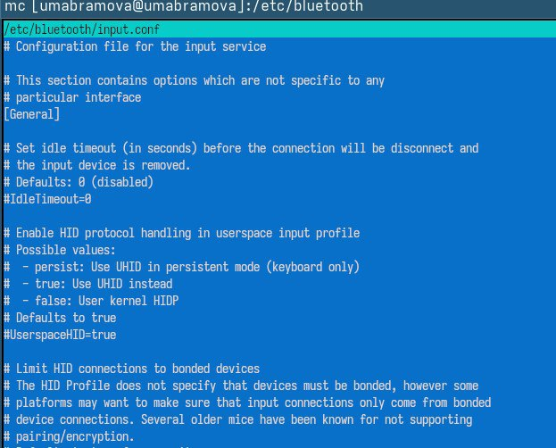

просмотр содержимого текстового файла

## Содержание исследования

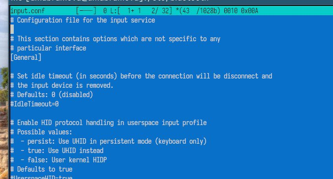

редактирование содержимого текстового файла

## Содержание исследования

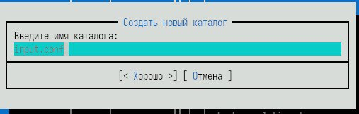

создание каталога

## Содержание исследования

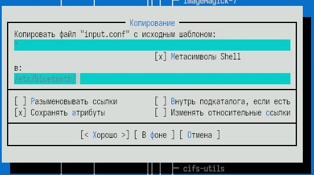

копирование в файлов

## Содержание исследования

С помощью соответствующих средств подменю Команда выполняю различные команды (рис. 11, 12, 13, 14)

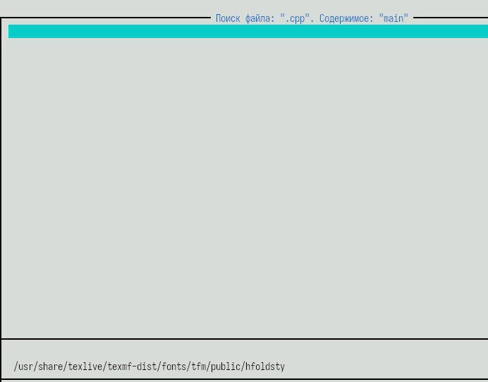

поиск в файловой системе файла с заданными условиями

## Содержание исследования

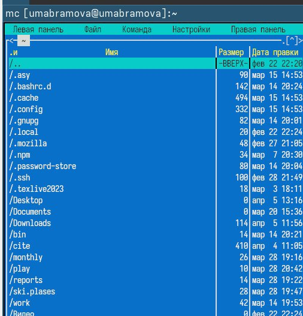

переход в домашних каталог

## Содержание исследования

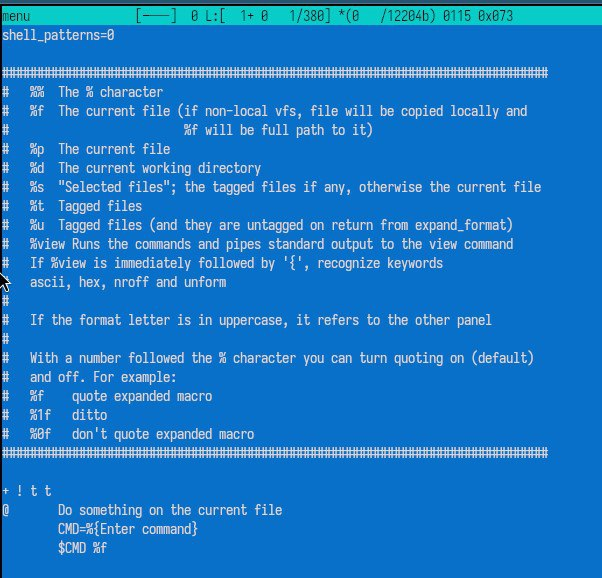

анализ файла меню

## Содержание исследования

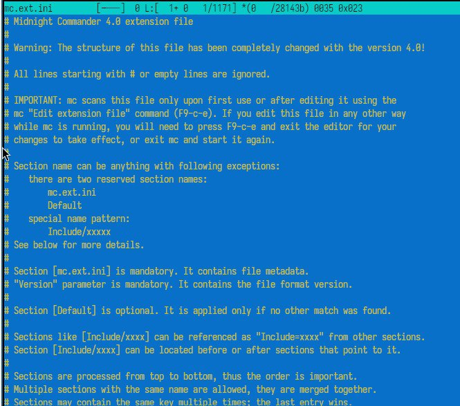

анализ файла расширений

## Содержание исследования

Вызвав подменю Настройки, осваиваю операции, определяющие структуру экрана mc (рис. 15, 16, 17, 18, 19, 20, 21, 22)

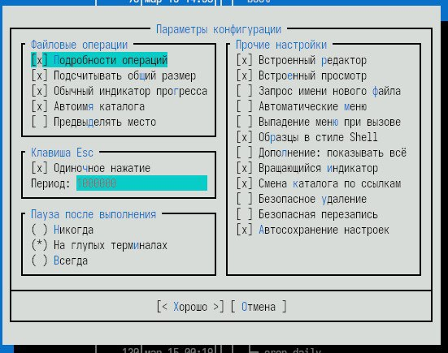

параметры конфигурации

## Содержание исследования

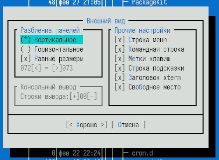

внешний вид

## Содержание исследования

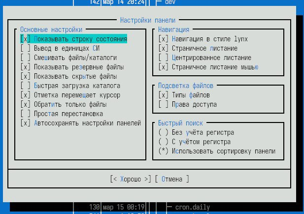

настройки панели

## Содержание исследования

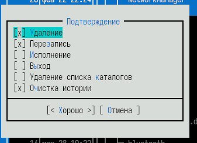

подтверждение

## Содержание исследования

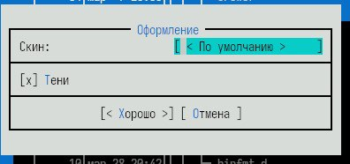

оформление

## Содержание исследования

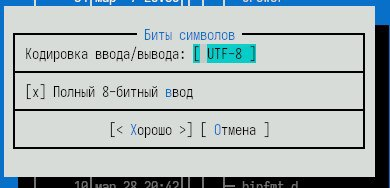

биты символов

## Содержание исследования

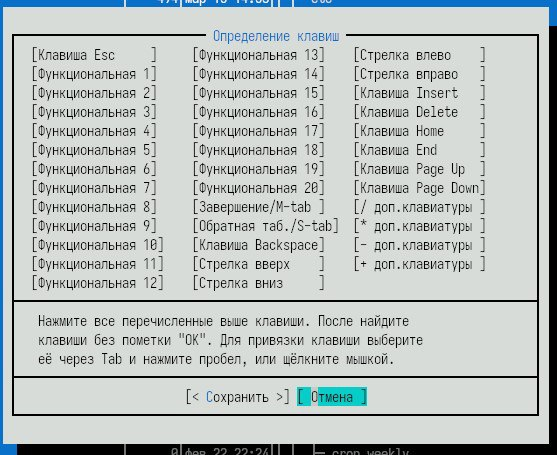

определение клавиш

## Содержание исследования

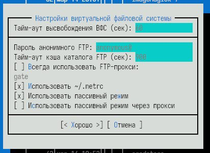

настройки виртуальной файловой системы

## Содержание исследования

### Задание по встроенному редактору mc

Создаю текстовой файл text.txt и откройте его с помощью редактора, затем вставляю в этот файл фрагмент текста, взятый из Интернета (рис. 23)

## Содержание исследования

[figure not shown]

создание и изменение файла

## Содержание исследования

С помощью горячей клавиши f8 удаляю строку, с помощью f5 копирую часть текста и вставляю на новую строчку (рис. 24)

## Содержание исследования

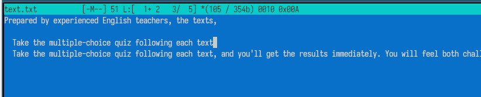

изменение файла

## Содержание исследования

С помощью f2 сохраняю файл, а благодаря ctrl+u отменяю последнее действие (рис. 25)

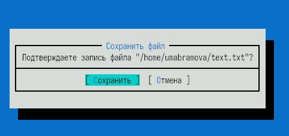

сохранение файла

## Содержание исследования

С помощью ctrl+x перехожу в конец файла и добавляю текст (рис. 26)

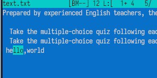

изменение файла

## Содержание исследования

Далее сохраняю и закрываю файл (рис. 28)

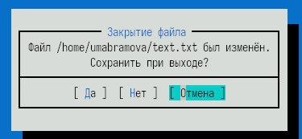

выход из файла

## Результаты

- В данной работе я ознакомилась с инструментами командной оболочки Midnight Commander. Приобрела навыки практической работы по просмотру каталогов и файлов

## Итоговый слайд

- Чем больше вы практикуетесь и пробуете новое, тем больше и чаще вы будете получать знаний и опыта в разных сферах.